# Optimal Treatment Analysis

## Outcome Variable

**Outcome Variable:** whz

## Predictor Variables

**Intervention Variable:** nchldlt5

**Adjustment Set:**

- arm
- W_mage
- meducyrs
- feducyrs
- hhwealth_quart
- hfoodsec
- W_mhtcm
- W_nrooms
- W_parity
- impfloor
- impsan
- safeh20
- delta_W_mage
- delta_meducyrs
- delta_feducyrs
- delta_hhwealth_quart
- delta_hfoodsec
- delta_W_mhtcm
- delta_W_nrooms
- delta_W_parity
- delta_impfloor
- delta_impsan
- delta_safeh20

## Stratifying Variables

The analysis was stratified on these variable(s):

- agecat
- studyid
- country

## Data Summary

| agecat | studyid | country | nchldlt5 | n_cell | n |
| --- | --- | --- | --- | --- | --- |
| Birth | ki1000108-IRC | INDIA | 1 | 72 | 245 |
| Birth | ki1000108-IRC | INDIA | 2+ | 173 | 245 |
| Birth | ki1017093c-NIH-Crypto | BANGLADESH | 1 | 15 | 16 |
| Birth | ki1017093c-NIH-Crypto | BANGLADESH | 2+ | 1 | 16 |
| Birth | kiGH5241-JiVitA-3 | BANGLADESH | 1 | 9384 | 9772 |
| Birth | kiGH5241-JiVitA-3 | BANGLADESH | 2+ | 388 | 9772 |
| 6 months | ki1000108-IRC | INDIA | 1 | 88 | 289 |
| 6 months | ki1000108-IRC | INDIA | 2+ | 201 | 289 |
| 6 months | ki1017093b-PROVIDE | BANGLADESH | 1 | 426 | 435 |
| 6 months | ki1017093b-PROVIDE | BANGLADESH | 2+ | 9 | 435 |
| 6 months | ki1017093c-NIH-Crypto | BANGLADESH | 1 | 507 | 512 |
| 6 months | ki1017093c-NIH-Crypto | BANGLADESH | 2+ | 5 | 512 |
| 6 months | ki1066203-TanzaniaChild2 | TANZANIA, UNITED REPUBLIC OF | 1 | 1390 | 1452 |
| 6 months | ki1066203-TanzaniaChild2 | TANZANIA, UNITED REPUBLIC OF | 2+ | 62 | 1452 |
| 6 months | ki1148112-LCNI-5 | MALAWI | 1 | 390 | 453 |
| 6 months | ki1148112-LCNI-5 | MALAWI | 2+ | 63 | 453 |
| 6 months | kiGH5241-JiVitA-3 | BANGLADESH | 1 | 10872 | 11234 |
| 6 months | kiGH5241-JiVitA-3 | BANGLADESH | 2+ | 362 | 11234 |
| 24 months | ki1000108-IRC | INDIA | 1 | 89 | 290 |
| 24 months | ki1000108-IRC | INDIA | 2+ | 201 | 290 |
| 24 months | ki1017093b-PROVIDE | BANGLADESH | 1 | 423 | 431 |
| 24 months | ki1017093b-PROVIDE | BANGLADESH | 2+ | 8 | 431 |
| 24 months | ki1017093c-NIH-Crypto | BANGLADESH | 1 | 357 | 361 |
| 24 months | ki1017093c-NIH-Crypto | BANGLADESH | 2+ | 4 | 361 |
| 24 months | ki1066203-TanzaniaChild2 | TANZANIA, UNITED REPUBLIC OF | 1 | 5 | 5 |
| 24 months | ki1066203-TanzaniaChild2 | TANZANIA, UNITED REPUBLIC OF | 2+ | 0 | 5 |
| 24 months | ki1148112-LCNI-5 | MALAWI | 1 | 277 | 321 |
| 24 months | ki1148112-LCNI-5 | MALAWI | 2+ | 44 | 321 |
| 24 months | kiGH5241-JiVitA-3 | BANGLADESH | 1 | 5434 | 5654 |
| 24 months | kiGH5241-JiVitA-3 | BANGLADESH | 2+ | 220 | 5654 |

The following strata were considered:

- agecat: 24 months, studyid: ki1000108-IRC, country: INDIA
- agecat: 24 months, studyid: ki1017093b-PROVIDE, country: BANGLADESH
- agecat: 24 months, studyid: ki1017093c-NIH-Crypto, country: BANGLADESH
- agecat: 24 months, studyid: ki1066203-TanzaniaChild2, country: TANZANIA, UNITED REPUBLIC OF
- agecat: 24 months, studyid: ki1148112-LCNI-5, country: MALAWI
- agecat: 24 months, studyid: kiGH5241-JiVitA-3, country: BANGLADESH
- agecat: 6 months, studyid: ki1000108-IRC, country: INDIA
- agecat: 6 months, studyid: ki1017093b-PROVIDE, country: BANGLADESH
- agecat: 6 months, studyid: ki1017093c-NIH-Crypto, country: BANGLADESH
- agecat: 6 months, studyid: ki1066203-TanzaniaChild2, country: TANZANIA, UNITED REPUBLIC OF
- agecat: 6 months, studyid: ki1148112-LCNI-5, country: MALAWI
- agecat: 6 months, studyid: kiGH5241-JiVitA-3, country: BANGLADESH
- agecat: Birth, studyid: ki1000108-IRC, country: INDIA
- agecat: Birth, studyid: ki1017093c-NIH-Crypto, country: BANGLADESH
- agecat: Birth, studyid: kiGH5241-JiVitA-3, country: BANGLADESH

### Dropped Strata

Some strata were dropped due to rare outcomes:

- agecat: Birth, studyid: ki1017093c-NIH-Crypto, country: BANGLADESH
- agecat: 24 months, studyid: ki1017093c-NIH-Crypto, country: BANGLADESH
- agecat: 24 months, studyid: ki1066203-TanzaniaChild2, country: TANZANIA, UNITED REPUBLIC OF

## Methods Detail

We’re interested in the causal parameters $E[Y_a]$ for all values of $a \in \mathcal{A}$. These parameters represent the mean outcome if, possibly contrary to fact, we intervened to set all units to have $A=a$. Under the randomization and positivity assumptions, these are identified by the statistical parameters $\psi_a=E_W[E_{Y|A,W}(Y|A=a,W)]$. In addition, we’re interested in the mean of $Y$, $E[Y]$ under no intervention (the observed mean). We will estimate these parameters by using SuperLearner to fit the relevant likelihood factors – $E_{Y|A,W}(Y|A=a,W)$ and $p(A=a|W)$, and then updating our likelihood fit using a joint TMLE.

For unadjusted analyses ($W=\{\}$), initial likelihoods were estimated using Lrnr_glm to estimate the simple $E(Y|A)$ and Lrnr_mean to estimate $p(A)$. For adjusted analyses, a small library containing Lrnr_glmnet, Lrnr_xgboost, and Lrnr_mean was used.

Having estimated these parameters, we will then use the delta method to estimate relative risks and attributable risks relative to a prespecified baseline level of $A$.

# Results Detail

## Results Plots

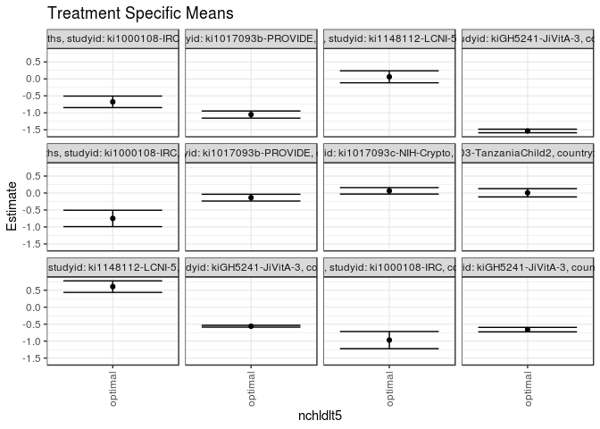

## Results Table

### Parameter: TSM

| agecat | studyid | country | intervention_level | baseline_level | estimate | ci_lower | ci_upper |
| --- | --- | --- | --- | --- | --- | --- | --- |
| Birth | ki1000108-IRC | INDIA | optimal | observed | -0.9699321 | -1.2233078 | -0.7165564 |
| Birth | kiGH5241-JiVitA-3 | BANGLADESH | optimal | observed | -0.6611831 | -0.7267576 | -0.5956086 |
| 6 months | ki1000108-IRC | INDIA | optimal | observed | -0.7484118 | -0.9898789 | -0.5069448 |
| 6 months | ki1017093b-PROVIDE | BANGLADESH | optimal | observed | -0.1362946 | -0.2362773 | -0.0363120 |
| 6 months | ki1017093c-NIH-Crypto | BANGLADESH | optimal | observed | 0.0648927 | -0.0302799 | 0.1600653 |
| 6 months | ki1066203-TanzaniaChild2 | TANZANIA, UNITED REPUBLIC OF | optimal | observed | 0.0076302 | -0.1145665 | 0.1298268 |
| 6 months | ki1148112-LCNI-5 | MALAWI | optimal | observed | 0.6062536 | 0.4358993 | 0.7766079 |
| 6 months | kiGH5241-JiVitA-3 | BANGLADESH | optimal | observed | -0.5613219 | -0.5877137 | -0.5349300 |
| 24 months | ki1000108-IRC | INDIA | optimal | observed | -0.6769968 | -0.8468428 | -0.5071508 |
| 24 months | ki1017093b-PROVIDE | BANGLADESH | optimal | observed | -1.0516057 | -1.1564293 | -0.9467822 |
| 24 months | ki1148112-LCNI-5 | MALAWI | optimal | observed | 0.0614627 | -0.1148515 | 0.2377769 |
| 24 months | kiGH5241-JiVitA-3 | BANGLADESH | optimal | observed | -1.5350877 | -1.5879936 | -1.4821818 |

### Parameter: E(Y)

| agecat | studyid | country | intervention_level | baseline_level | estimate | ci_lower | ci_upper |
| --- | --- | --- | --- | --- | --- | --- | --- |
| Birth | ki1000108-IRC | INDIA | observed | observed | -1.0094286 | -1.2311616 | -0.7876956 |
| Birth | kiGH5241-JiVitA-3 | BANGLADESH | observed | observed | -0.7487659 | -0.7726563 | -0.7248754 |
| 6 months | ki1000108-IRC | INDIA | observed | observed | -0.6243253 | -0.7833786 | -0.4652719 |
| 6 months | ki1017093b-PROVIDE | BANGLADESH | observed | observed | -0.1469923 | -0.2464550 | -0.0475297 |
| 6 months | ki1017093c-NIH-Crypto | BANGLADESH | observed | observed | 0.0572461 | -0.0359459 | 0.1504381 |
| 6 months | ki1066203-TanzaniaChild2 | TANZANIA, UNITED REPUBLIC OF | observed | observed | 0.0817637 | 0.0194495 | 0.1440778 |
| 6 months | ki1148112-LCNI-5 | MALAWI | observed | observed | 0.4996468 | 0.4052394 | 0.5940542 |
| 6 months | kiGH5241-JiVitA-3 | BANGLADESH | observed | observed | -0.5754055 | -0.5983356 | -0.5524753 |
| 24 months | ki1000108-IRC | INDIA | observed | observed | -0.7841264 | -0.8946395 | -0.6736134 |
| 24 months | ki1017093b-PROVIDE | BANGLADESH | observed | observed | -0.8670766 | -0.9643669 | -0.7697862 |
| 24 months | ki1148112-LCNI-5 | MALAWI | observed | observed | -0.0275234 | -0.1369083 | 0.0818616 |
| 24 months | kiGH5241-JiVitA-3 | BANGLADESH | observed | observed | -1.3091670 | -1.3388782 | -1.2794557 |

### Parameter: PAR

| agecat | studyid | country | intervention_level | baseline_level | estimate | ci_lower | ci_upper |
| --- | --- | --- | --- | --- | --- | --- | --- |
| Birth | ki1000108-IRC | INDIA | optimal | observed | -0.0394965 | -0.1904286 | 0.1114356 |
| Birth | kiGH5241-JiVitA-3 | BANGLADESH | optimal | observed | -0.0875827 | -0.1541642 | -0.0210013 |
| 6 months | ki1000108-IRC | INDIA | optimal | observed | 0.1240866 | -0.0916152 | 0.3397884 |
| 6 months | ki1017093b-PROVIDE | BANGLADESH | optimal | observed | -0.0106977 | -0.0307447 | 0.0093492 |
| 6 months | ki1017093c-NIH-Crypto | BANGLADESH | optimal | observed | -0.0076466 | -0.0166392 | 0.0013460 |
| 6 months | ki1066203-TanzaniaChild2 | TANZANIA, UNITED REPUBLIC OF | optimal | observed | 0.0741335 | -0.0317759 | 0.1800429 |
| 6 months | ki1148112-LCNI-5 | MALAWI | optimal | observed | -0.1066068 | -0.2504892 | 0.0372756 |
| 6 months | kiGH5241-JiVitA-3 | BANGLADESH | optimal | observed | -0.0140836 | -0.0272940 | -0.0008732 |
| 24 months | ki1000108-IRC | INDIA | optimal | observed | -0.1071296 | -0.2418598 | 0.0276006 |
| 24 months | ki1017093b-PROVIDE | BANGLADESH | optimal | observed | 0.1845292 | 0.1132848 | 0.2557735 |
| 24 months | ki1148112-LCNI-5 | MALAWI | optimal | observed | -0.0889861 | -0.2285440 | 0.0505719 |
| 24 months | kiGH5241-JiVitA-3 | BANGLADESH | optimal | observed | 0.2259207 | 0.1765864 | 0.2752551 |